# final Project

Christoffer M. Kramer

26/11/2020

# Introduction

**Additional information** * *Libraries:* I’m gonna use the following libraries:

```r
library(tidyverse) #Cleaning data
library(tidytext) #Text-mining
library(ggplot2) #Plotting
library(ggwordcloud) #Plotting word clouds
library(rvest)  #Web scraping
library(lubridate) #Cleaning Dates
library(zoo) #Dealing with na's
library(reshape2) #transform text to term document matrix
library(wordcloud) #Make comparison and commonality word clouds
```

## Web scraping

```r
# Scrape Debate function --------------------------------------------------
scrape_debates <- function(website) {
  p_html <-  read_html(website) %>%
    html_nodes("p") %>%
    html_text()

  vect_p_html <- c(p_html) #Save the output in a vector.
}

# Get and store links to debates ---------------------------------------------------
link_html <- read_html("https://www.debates.org/voter-education/debate-transcripts/") %>%
  html_nodes("blockquote") %>%
  html_children() %>%
  html_nodes("a")  %>%
  html_attr("href")

vect_link <- c(link_html) #save the output in a vector
vect_link #Check output
```

```
##  [1] "https://www.debates.org/voter-education/debate-transcripts/september-29-2020-debate-transcript/"
##  [2] "http://debates.org/voter-education/debate-transcripts/vice-presidential-debate-at-the-university-of-utah-in-salt-lake-city-utah/"
##  [3] "https://www.debates.org/voter-education/debate-transcripts/october-22-2020-debate-transcript/"
##  [4] "/voter-education/debate-transcripts/september-26-2016-debate-transcript/"
##  [5] "/voter-education/debate-transcripts/october-4-2016-debate-transcript/"
##  [6] "/voter-education/debate-transcripts/october-9-2016-debate-transcript/"
##  [7] "/voter-education/debate-transcripts/october-19-2016-debate-transcript/"
##  [8] "/voter-education/debate-transcripts/october-3-2012-debate-transcript/"
##  [9] "/voter-education/debate-transcripts/october-11-2012-the-biden-romney-vice-presidential-debate/"
## [10] "/voter-education/debate-transcripts/october-16-2012-the-second-obama-romney-presidential-debate/"
## [11] "/voter-education/debate-transcripts/october-22-2012-the-third-obama-romney-presidential-debate/"
## [12] "/voter-education/debate-transcripts/2008-debate-transcript/"
## [13] "/voter-education/debate-transcripts/2008-debate-transcript-2/"
## [14] "/voter-education/debate-transcripts/october-7-2008-debate-transcrip/"
## [15] "/voter-education/debate-transcripts/october-15-2008-debate-transcript/"
```

[output cut: 33 more lines]

When I wrote the portfolio on web scraping, the transcripts for the 2020 debates had not yet been uploaded. Now that they have, they need some additional cleaning. I will, therefore, remove the hostname ("https://www.debates.org/) from the strings and replace them with the path to each transcript.

```r
#Clean messy links
vect_link[1] <- "/voter-education/debate-transcripts/september-29-2020-debate-transcript/"
vect_link[2] <- "/voter-education/debate-transcripts/vice-presidential-debate-at-the-university-of-utah-in-salt-lake-city-utah/"
vect_link[3] <- "/voter-education/debate-transcripts/october-22-2020-debate-transcript/"
```

```r
# Loop through the links and store the content ----------------------------
all_debates_raw <- tibble()

for (link in vect_link[!is.na(vect_link)]) {
  date <- str_extract(link, "[A-Za-z]+-\\d+-\\d+")

 if(is.na(date)) {

  date <- str_extract(link, ".+")

 } #end if

  website <- paste0("https://www.debates.org/", link)
  debate <- scrape_debates(website) #create an object storing the transcript
  debate <- tibble(line = 1:length(debate), text = debate, date = date)
  all_debates_raw <- bind_rows(all_debates_raw, debate) #row bind the transcript to all_debates
} #end loop
```

## Data Cleaning and Data Wrangling

I have created a data set called “candidates_since 1960.csv”, which contains a list of presidential and vice presidential candidates since 1960. This data set will be used for data wrangling. In order to keep my raw data intact, I will save it in an object called *candidates*. After that I transform the *candidates* to a *tibble*, since I prefer tibbles over base R’s *data.frame*. Lastly, I mutate all last names to upper case. This is done because each speaker in the transcripts is identified with their last name written in uppercase. By writing all names in uppercase it will therefore be easier to match their last name in the transcripts using a regex.

```r
candidates <- read.csv(file = "../data/candidates_since_1960.csv", sep = ";") #Load csv
candidates <- tibble(candidates) %>%  #make data frame a tibble.
  mutate(last_name = toupper(last_name)) #Make all names uppercase
```

Let’s check the data set out:

```r
head(candidates)
```

| year | party | first_name | last_name | position |
| --- | --- | --- | --- | --- |
| 2020 | R | Donald | TRUMP | president |
| 2020 | D | Joe | BIDEN | president |
| 2016 | R | Donald | TRUMP | president |
| 2016 | D | Hillary | CLINTON | president |
| 2012 | D | Barack | OBAMA | president |
| 2012 | R | Mitt | ROMNEY | president |

As you can see this data_set provides every year a candidate ran, their first name, their last name, and their position (president or vice_president).

In order to make my data reproducible, I will save my results from the web-scraping, which is currently stored in the object *all_debates_raw*, in a csv-file. By doing this, I can make sure, that my data stays intact even if the website debates.org ceases to exist. Lastly, I create the tibble *all_debates* which contains the cs to a tibble:

```r
# Save transcripts as csv and create a tibble --------------------------------------------------------------
write.csv(all_debates_raw, "../data/all_debates_raw.csv", row.names=FALSE) #create csv
all_debates <- read.csv("../data/all_debates_raw.csv") #load csv
all_debates <- tibble(all_debates) #make data frame a tibble
```

Let’s check it out:

```r
head(all_debates)
```

| line | text | date |
| --- | --- | --- |
| 1 | Presidential Debate at Case Western Reserve University and Cleveland Clinic in Cleveland, Ohio | september-29-2020 |
| 2 | September 29, 2020 | september-29-2020 |
| 3 | PARTICIPANTS:Former Vice President Joe Biden (D) and\nPresident Donald Trump (R) | september-29-2020 |
| 4 | MODERATOR:Chris Wallace (Fox News) | september-29-2020 |
| 5 | WALLACE: Good evening from the Health Education Campus of Case Western Reserve University and the Cleveland Clinic. I’m Chris Wallace of Fox News and I welcome you to the first of the 2020 presidentia… | september-29-2020 |
| 6 | This debate is being conducted under health and safety protocols designed by the Cleveland Clinic, which is serving as the health security advisor to the Commission for all four debates. As a precauti… | september-29-2020 |

As you can see, this data set still needs a lot of cleaning, in order to follow Hadley Wickhams principles for tidy data (Wickham, 2014). The data does not tell, who is speaking or at what their party affiliation is. Moreover, the dates do not follow the datacarpetry’s recommendation of seperating year, month and day into seperate column (datacarpentry.org, n.d.).

### Cleaning dates

I will start the data wrangling by cleaning the dates. this is done by creating a function. This function only works if the provided data is a string. It uses str_replace_all to replace a pattern with a new string.

```r
#Functions that cleans names by replacing an existing string with a new string
#Will only mutate if the provided data is a string.
clean_dates <- function(dataset, old_pattern, new_replacement) {
  mutate_if(dataset,
            is.character,
            str_replace_all, pattern = old_pattern, replacement = new_replacement)
}
```

Now I need to find all dates, which are wrong. I can does not match a regex with the function *filter* and *grep*. This regex is the same, as the one used in the previous loop. However with the *!* operator, it inverts the regex, thereby returning strings that do not follow the structure of “month-day-year” (e.g. “october-20-2020”). I then store the output in an object called *wrong names*.

```r
#Find the wrong dates
wrong_dates <- all_debates %>%
  filter(!grepl("[A-Za-z]+-\\d+-\\d+", date)) %>%
  select(date) %>%
  unique()
```

Let’s check out *wrong_dates*.

```r
wrong_dates
```

| date |
| --- |
| /voter-education/debate-transcripts/vice-presidential-debate-at-the-university-of-utah-in-salt-lake-city-utah/ |
| /voter-education/debate-transcripts/2008-debate-transcript/ |
| /voter-education/debate-transcripts/2008-debate-transcript-2/ |
| /voter-education/debate-transcripts/2000-debate-transcripts-translations/ |

There 4 wrong dates 3 of them don’t include a date, and the last is a link to the translations of the debate_transcripts. Firstly I remove the translation page from *all_debates*:

```r
#Remove translations page from list of dates and the dataset
all_debates <- all_debates[!(all_debates$date == "/voter-education/debate-transcripts/2000-debate-transcripts-translations/"),]
```

Then I replace the wrong dates with the correct dates using my function *clean_dates*.

```r
#Replace wrong date with correct date
all_debates <- clean_dates(all_debates, old_pattern = "voter-education/debate-transcripts/vice-presidential-debate-at-the-university-of-utah-in-salt-lake-city-utah/",
                           new_replacement = "october-7-2020")

all_debates <- clean_dates(all_debates, old_pattern ="/voter-education/debate-transcripts/2008-debate-transcript/",
                           new_replacement = "september-26-2008")

all_debates <- clean_dates(all_debates, old_pattern ="/voter-education/debate-transcripts/2008-debate-transcript-2/",
                           new_replacement = "october-2-2008")
```

Let’s check out the result:

```r
all_debates$date %>%
  unique()
```

```
##  [1] "september-29-2020" "/october-7-2020"   "october-22-2020"
##  [4] "september-26-2016" "october-4-2016"    "october-9-2016"
##  [7] "october-19-2016"   "october-3-2012"    "october-11-2012"
## [10] "october-16-2012"   "october-22-2012"   "september-26-2008"
## [13] "october-2-2008"    "october-7-2008"    "october-15-2008"
## [16] "october-13-2004"   "october-8-2004"    "october-5-2004"
## [19] "september-30-2004" "october-3-2000"    "october-5-2000"
## [22] "october-11-2000"   "october-17-2000"   "october-6-1996"
## [25] "october-9-1996"    "october-16-1996"   "october-11-1992"
## [28] "october-13-1992"   "october-15-1992"   "october-19-1992"
## [31] "september-25-1988" "october-5-1988"    "october-13-1988"
## [34] "october-7-1984"    "october-11-1984"   "october-21-1984"
## [37] "september-21-1980" "october-28-1980"   "september-23-1976"
## [40] "october-6-1976"    "october-22-1976"   "september-26-1960"
## [43] "october-7-1960"    "october-13-1960"   "october-21-1960"
```

It appears to be working. However, I still need to seperate day, month, and year, into different columns. This is done with the lubridate package (Grolemund & Wickham, 2011):

```r
# Make "date" a proper date with different columns for day, month and year ------------------------------------------------
all_debates <- all_debates %>%
  mutate(date = mdy(date)) %>%
  mutate(day = day(date),
         month = month(date),
         year = year(date)
  )
```

Let’s see if it works:

```r
head(all_debates)
```

| line | text | date | day | month | year |
| --- | --- | --- | --- | --- | --- |
| 1 | Presidential Debate at Case Western Reserve University and Cleveland Clinic in Cleveland, Ohio | 2020-09-29 | 29 | 9 | 2020 |
| 2 | September 29, 2020 | 2020-09-29 | 29 | 9 | 2020 |
| 3 | PARTICIPANTS:Former Vice President Joe Biden (D) and\nPresident Donald Trump (R) | 2020-09-29 | 29 | 9 | 2020 |
| 4 | MODERATOR:Chris Wallace (Fox News) | 2020-09-29 | 29 | 9 | 2020 |
| 5 | WALLACE: Good evening from the Health Education Campus of Case Western Reserve University and the Cleveland Clinic. I’m Chris Wallace of Fox News and I welcome you to the first of the 2020 presidentia… | 2020-09-29 | 29 | 9 | 2020 |
| 6 | This debate is being conducted under health and safety protocols designed by the Cleveland Clinic, which is serving as the health security advisor to the Commission for all four debates. As a precauti… | 2020-09-29 | 29 | 9 | 2020 |

It works. Now I’m ready to differentiate between speakers.

### Who is speakning?

In the transcript Different speakers are marked the following way: “LAST_NAME: Speech”. So When Donald Trump speaks it is marked like this: “TRUMP: …”. When no names are applied it is always the last named speaker who is talking. However, in the older debates speakers are referred to as MR. or MS. , and some speakers have small and lowercase letters in their names (e.g. the moderater “McGee” ). In order to extract all speakers, I use a series str_extract and a regexes to remove semicolon and MR. or MS., I then save the result as a tibble in an object called *last_name*.

```r
# Find all names and save as a tibble --------------------------------------------------------------------------------
last_name <- str_extract(all_debates$text, "^[A-Za-z]+:|^M[RS]\\..+:") %>%
  str_extract("[A-Za-z]+:") %>% #remove MR. and MS.
  str_extract("[A-Za-z]+") #Remove semicolon
last_name <- tibble(last_name)
```

Then I combine the columns of *all_debates* and *last_name*.

```r
# bind column to all debates and fill out every cell in last_name, make all last_names uppercase ------------------------------------------------------------------------------------------
all_debates <- cbind(all_debates, last_name)
```

Let’s check it out:

```r
head(all_debates) %>%
  select(line,last_name)
```

|  | line | last_name |
| --- | --- | --- |
| 1 | 1 | NA |
| 2 | 2 | NA |
| 3 | 3 | PARTICIPANTS |
| 4 | 4 | MODERATOR |
| 5 | 5 | WALLACE |
| 6 | 6 | NA |

The names “Participants” and “Moderator”, are a result of every transcript starting with a declaration of who is moderation and who is participating. These are dealt with later. There are some NA’s. However, these are easily explained. The first NA’s are because no one has spoken yet. The NA after “WALLACE” is because Wallace is still speaking. Every time a speaking is not mentioned, it is the last named speaker who is speaking. Therefore by replacing all NA’s with the previous known value, it is possible to assign a speaker to each line. This is done with the function *na.locf* from the *zoo* package (Zeileis & Grothendieck, 2005).

```r
all_debates <- na.locf(all_debates)
```

Lastly, I transform all Last_names to Uppercase so I can do a join.

```r
all_debates <- all_debates %>%
  mutate(last_name = toupper(last_name))
```

Then I left_join *all_debates* with *candidates* by column *last_name* and *year*. Then I replace all NA’s with the string “not_a_candidate”, everywhere. This is done in order to follow Broman and Woo’s principles of data organization in spreadsheets, which, among other, states, that NA’s should not be included in spreadsheets (Broman & Woo: 4, 2018).

```r
#Combine the tibble with candidates and the debates by last_name and year ---------------------------------------------
all_debates <- left_join(all_debates, candidates, by = c("last_name" = "last_name", "year" = "year"))
all_debates[is.na(all_debates)] <- "not_a_candidate" #fill na's
```

Now in, order to not have the declarition of each speaker influence my analysis, I’m going to use the same regex as previously for finding names, and then remove them, using the function **str_remove**.

```r
# Remove the names from the text --------------------------------------------------------------------------------------
 all_debates <- all_debates %>%
   mutate(text = str_remove(text, "^[A-Za-z]+:|^M[RS]\\..+:"))
```

Lastly, I will reorder the columns so *first_name* and *last_name* are placed in front of the text. This is purely an aestethic choice.

```r
# reorder columns ----------------------------------------------------------------------------------------------------
all_debates <- all_debates %>%
  relocate(last_name, .before = text)
all_debates <- all_debates %>%
  relocate(first_name, .before = last_name)
```

Now let’s check the result:

```r
head(all_debates)
```

|  | line | first_name | last_name | text | date | day | month | year | party | position |
| --- | --- | --- | --- | --- | --- | --- | --- | --- | --- | --- |
| 1 | 3 | not_a_candidate | PARTICIPANTS | Former Vice President Joe Biden (D) and\nPresident Donald Trump (R) | 2020-09-29 | 29 | 9 | 2020 | not_a_candidate | not_a_candidate |
| 2 | 4 | not_a_candidate | MODERATOR | Chris Wallace (Fox News) | 2020-09-29 | 29 | 9 | 2020 | not_a_candidate | not_a_candidate |
| 3 | 5 | not_a_candidate | WALLACE | Good evening from the Health Education Campus of Case Western Reserve University and the Cleveland Clinic. I’m Chris Wallace of Fox News and I welcome you to the first of the 2020 presidential debates… | 2020-09-29 | 29 | 9 | 2020 | not_a_candidate | not_a_candidate |
| 4 | 6 | not_a_candidate | WALLACE | This debate is being conducted under health and safety protocols designed by the Cleveland Clinic, which is serving as the health security advisor to the Commission for all four debates. As a precauti… | 2020-09-29 | 29 | 9 | 2020 | not_a_candidate | not_a_candidate |
| 5 | 7 | Joe | BIDEN | How you doing, man? | 2020-09-29 | 29 | 9 | 2020 | D | president |
| 6 | 8 | Donald | TRUMP | How are you doing? | 2020-09-29 | 29 | 9 | 2020 | R | president |

Now my data set follows a nice and tidy structure. This will make the analyzis and plotting easier.

```r
save_plot_pdf <- function(name, path_destination = "../plots/", width_value = 8.26, height_value = 11.69){
  dev.copy(pdf, paste(path_destination, name, ".pdf", sep = ""), width= width_value, height= height_value) #Units are inches
  dev.off()
}
```

# Text-mining

```r
my_stop_words <- tibble(word = c("uh", "uhh")) #custom stop words

debate_words <- all_debates %>%
  unnest_tokens(word, text) %>%
  filter(!grepl("[[:digit:]]", word)) %>%  #Remove digits
  anti_join(my_stop_words)
```

```r
debate_words
```

|  | line | first_name | last_name | date | day | month | year | party | position | word |
| --- | --- | --- | --- | --- | --- | --- | --- | --- | --- | --- |
| 1 | 3 | not_a_candidate | PARTICIPANTS | 2020-09-29 | 29 | 9 | 2020 | not_a_candidate | not_a_candidate | former |
| 1.1 | 3 | not_a_candidate | PARTICIPANTS | 2020-09-29 | 29 | 9 | 2020 | not_a_candidate | not_a_candidate | vice |
| 1.2 | 3 | not_a_candidate | PARTICIPANTS | 2020-09-29 | 29 | 9 | 2020 | not_a_candidate | not_a_candidate | president |
| 1.3 | 3 | not_a_candidate | PARTICIPANTS | 2020-09-29 | 29 | 9 | 2020 | not_a_candidate | not_a_candidate | joe |
| 1.4 | 3 | not_a_candidate | PARTICIPANTS | 2020-09-29 | 29 | 9 | 2020 | not_a_candidate | not_a_candidate | biden |
| 1.5 | 3 | not_a_candidate | PARTICIPANTS | 2020-09-29 | 29 | 9 | 2020 | not_a_candidate | not_a_candidate | d |
| 1.6 | 3 | not_a_candidate | PARTICIPANTS | 2020-09-29 | 29 | 9 | 2020 | not_a_candidate | not_a_candidate | and |
| 1.7 | 3 | not_a_candidate | PARTICIPANTS | 2020-09-29 | 29 | 9 | 2020 | not_a_candidate | not_a_candidate | president |
| 1.8 | 3 | not_a_candidate | PARTICIPANTS | 2020-09-29 | 29 | 9 | 2020 | not_a_candidate | not_a_candidate | donald |
| 1.9 | 3 | not_a_candidate | PARTICIPANTS | 2020-09-29 | 29 | 9 | 2020 | not_a_candidate | not_a_candidate | trump |

[output cut: 9990 more lines]

## Stop word filtering

```r
stop_words_removed <- debate_words %>%
  mutate(word = gsub("\u2019", "'", word)) %>%  #Make read it at unix
  anti_join(stop_words)
```

## Plotting Stop word filtering

Let’s try plotting. First we create a plotting function

```r
plot_wordclouds <- function(data_set, label_value = word, size_value = n, max_size = 10, color_value = n, shape_value ="diamond") {
    ggplot(data_set, aes(label = {{label_value}}, size = {{size_value}})) +
    geom_text_wordcloud_area(aes(color = {{color_value}}), shape = shape_value) +
    scale_size_area(max_size) +
    theme_minimal()
    }
```

```r
create_comparison_cloud <- function(data_set,  title_value = "", color_values = c("darkred", "darkgreen"), title_bg_colors = color_values, title_text_colors = c("white")) {
  data_set %>%
  comparison.cloud(colors = color_values,
                   random.order = FALSE,
                   scale = c(2, 0.2),
                   title.bg.colors = title_bg_colors,
                   title.colors = title_text_colors,
                   title.size = 1) +
title(main = title_value, line = 1)

}
```

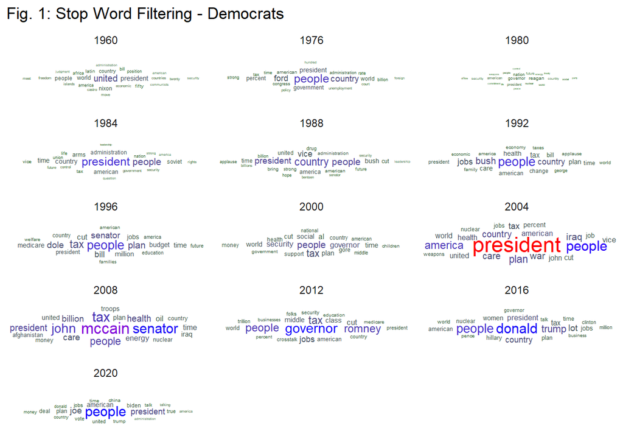

Fig. 1: Wordcloud generated from stop word filtering - Democrats

```r
stop_words_removed %>%
  filter(party == "D") %>%
  count(year, party, word, sort = TRUE) %>%
  group_by(year) %>%
  slice_max(order_by = n, n = 20) %>%
  plot_wordclouds() +
  scale_color_gradientn(colors = c("darkgreen","blue","red")) +
  facet_wrap(~year, ncol = 3, scales = "free") +
  labs(title = "Fig. 1: Stop Word Filtering - Democrats")
```

```r
save_plot_pdf("fig_1")
```

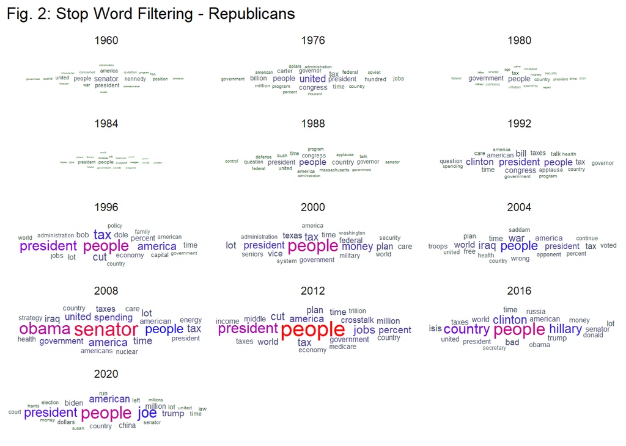

Fig. 2: Wordcloud generated from stop word filtering - Republicans

```r
stop_words_removed %>%
 filter(party == "R") %>%
  count(year, party, word, sort = TRUE) %>%
  group_by(year) %>%
  slice_max(order_by = n, n = 20) %>%
  plot_wordclouds() +
  scale_color_gradientn(colors = c("darkgreen","blue","red")) +
  facet_wrap(~year, ncol = 3, scales = "free") +
   labs(title = "Fig. 2: Stop Word Filtering - Republicans")
```

```r
save_plot_pdf("fig_2")
```

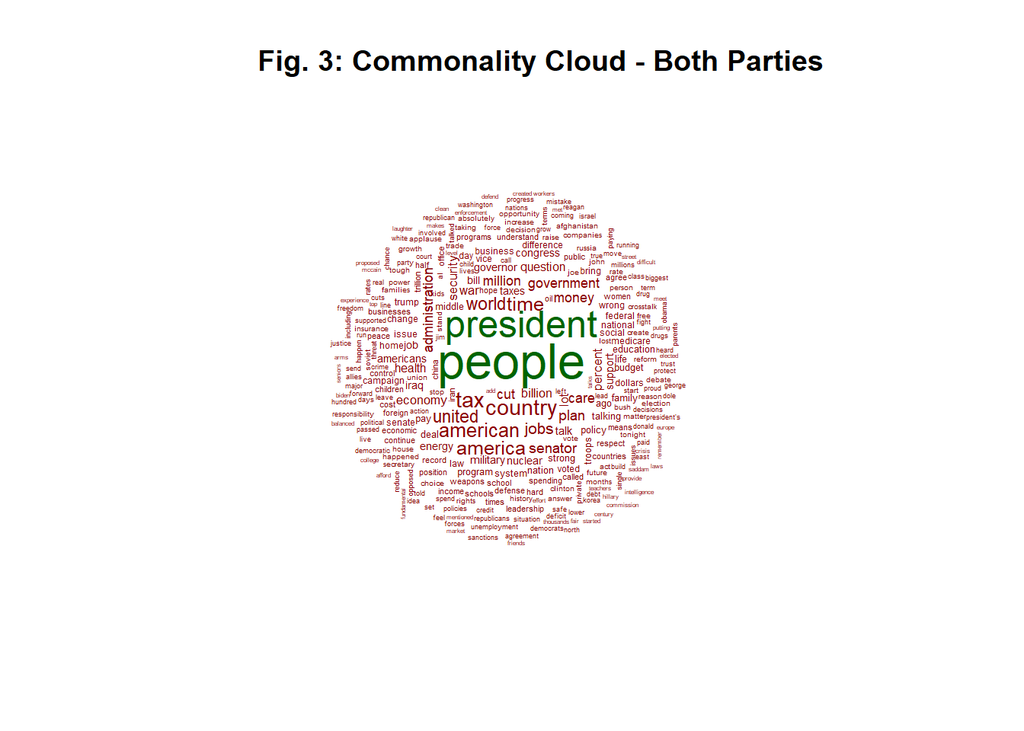

Fig. 3: Commonality cloud generated by stop word filtering

```
## integer(0)
```

```r
stop_words_removed %>%
  filter(grepl("[DR]", party)) %>%
  count(party, word, sort = TRUE) %>%
  acast(word ~ party, value.var = "n", fill = 0) %>%
  commonality.cloud(colors = c("darkred", "darkgreen"),
                   random.order = FALSE,
                   scale = c(2, 0.2)) +
  title(main = "Fig. 3: Commonality Cloud - Both Parties")
```

```r
save_plot_pdf("fig_3")
```

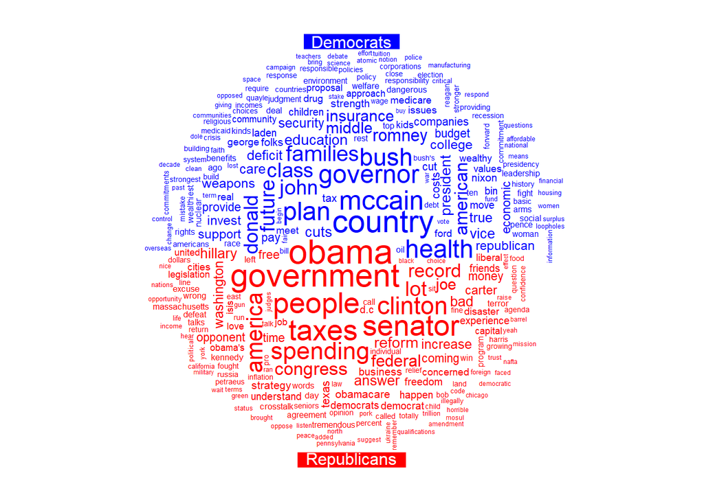

Fig. 4: Comparison cloud generated by stop word filtering

```
## integer(0)
```

```r
stop_words_removed  %>%
  filter(grepl("[DR]", party)) %>%
  mutate(party = str_replace(party, "D", "Democrats")) %>%
  mutate(party = str_replace(party, "R", "Republicans")) %>%
  count(party, word, sort = TRUE) %>%
  acast(word ~ party, value.var = "n", fill = 0) %>%
  create_comparison_cloud(color_values = c("Blue", "Red"))
```

```r
save_plot_pdf(name ="fig_4", width_value = NULL, height_value = NULL)
```

## TF_IDF

```r
word_count_year <- debate_words %>%
  count(year, word, sort = TRUE)


total_words_year <- word_count_year %>%
  group_by(year) %>%
  summarise(total = sum(n))



word_count_year <- left_join(word_count_year, total_words_year)

word_tf_idf <- word_count_year %>%
  bind_tf_idf(word, year, n)
```

## TF_IDF plotting

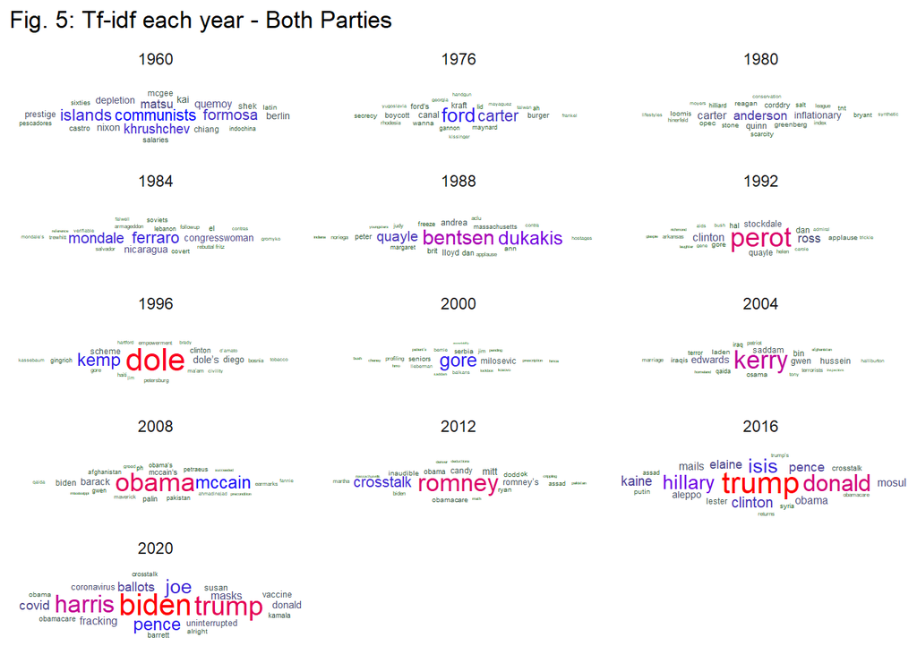

Fig. 5: TF-IDF each year

```r
word_tf_idf %>%
  group_by(year) %>%
  slice_max(order_by = tf_idf, n = 20) %>%
 plot_wordclouds(size_value = tf_idf, color_value = tf_idf) +
  scale_color_gradientn(colors = c("darkgreen","blue","red")) +
   facet_wrap(~year, ncol = 3, scales = "free") +
  labs(title = "Fig. 5: Tf-idf each year - Both Parties")
```

```r
save_plot_pdf("fig_5")
```

What about overall?

```r
word_count_party <- debate_words %>%
  count(party, word, sort = TRUE)

total_words_party <- word_count_party %>%
  group_by(party) %>%
  summarise(total = sum(n))

word_count <- left_join(word_count_party, total_words_party)

word_tf_idf <- word_count_party %>%
  bind_tf_idf(word, party, n)
```

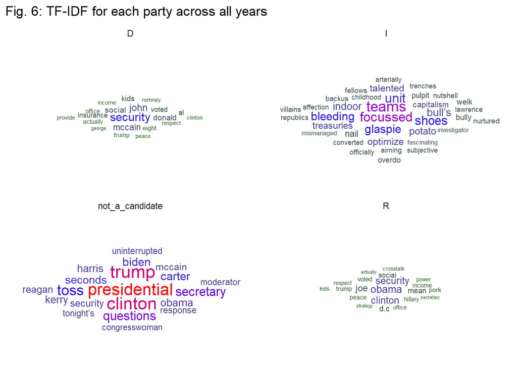

Fig. 6: TF-IDF for each party across all years

```r
word_tf_idf %>%
  group_by(party) %>%
  slice_max(order_by = tf_idf, n = 20) %>%
  plot_wordclouds(size_value = tf_idf, color_value = tf_idf) +
  scale_color_gradientn(colors = c("darkgreen","blue","red")) +
  facet_wrap(~party, ncol = 2, scales = "free") +
  labs(title = "Fig. 6: TF-IDF for each party across all years" )
```

```r
save_plot_pdf("fig_6")
```

## Sentiment analysis

```r
distortion_words <- tibble(word = c("trump", "vice"))

 sentiment_debate_words <- debate_words %>%
  anti_join(distortion_words) %>%
  inner_join(get_sentiments("afinn")) %>%
  inner_join(get_sentiments("bing"))
```

### Plot overall sentiment

```r
#Plot Pie chart function
plot_pie_chart <- function(data_set, fill_value = sentiment){
  data_set %>%
  mutate(total = sum(n)) %>%
  mutate(share = n/total) %>%
  ggplot() +
  geom_bar(aes(x = "", y = share, fill = {{fill_value}}), stat = "identity") +
  scale_fill_brewer(palette = "Set3") +
  coord_polar("y", start = 0) +
  theme(axis.text.x = element_blank())
  }
```

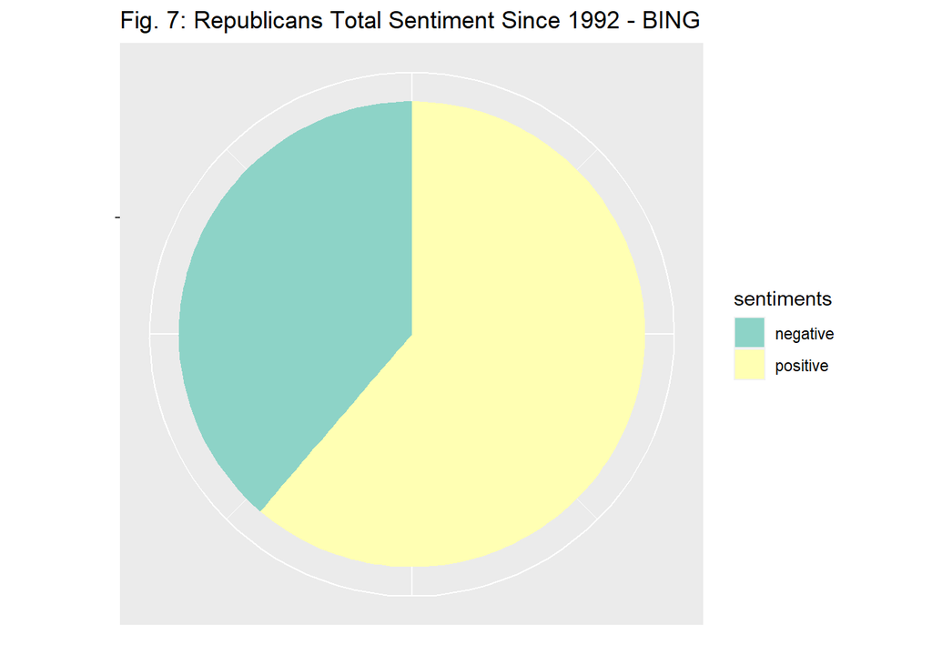

Fig. 7: Total Republican sentiment since 1992

```r
#Pie chart Republicans - over all sentiment
sentiment_debate_words %>%
filter (year >= 1992) %>%
filter(party == "R") %>%
count(sentiment, sort = TRUE) %>%
plot_pie_chart() +
labs(title = "Fig. 7: Republicans Total Sentiment Since 1992 - BING",
       x = "",
       y = "",
       fill = "sentiments")
```

```r
save_plot_pdf("fig_7")
```

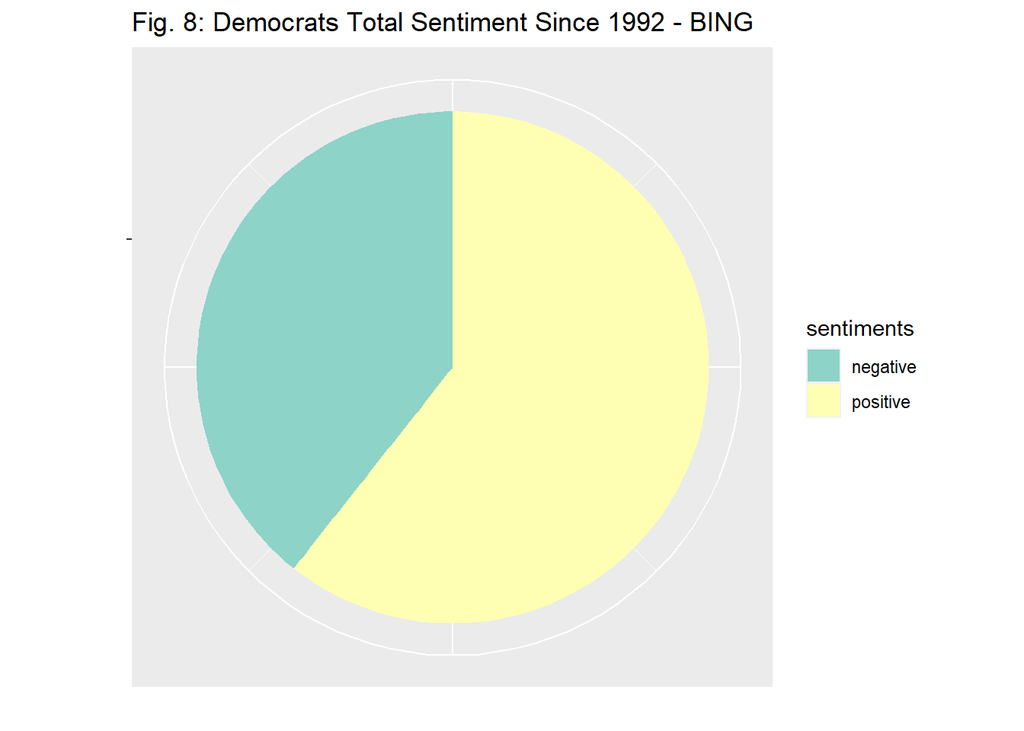

Fig. 8: Total democratic sentiment since 1992

```r
#Pie chart Democrats - over all sentiment
sentiment_debate_words %>%
filter(year >= 1992) %>%
filter(party == "D") %>%
count(sentiment) %>%
plot_pie_chart() +
labs(title = "Fig. 8: Democrats Total Sentiment Since 1992 - BING",
       x = "",
       y = "",
       fill = "sentiments")
```

```r
save_plot_pdf("fig_8")
```

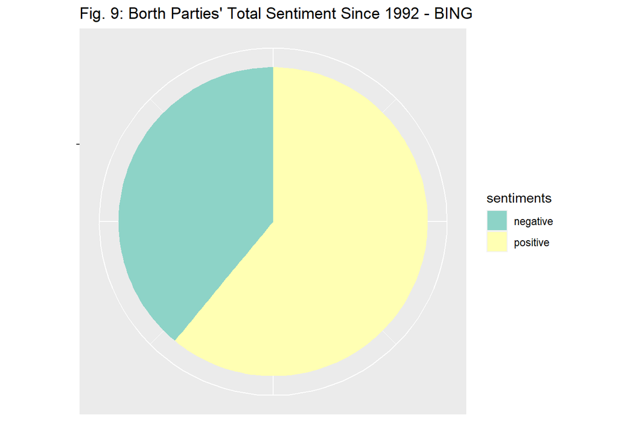

```r
#Pie chart Democrats - over all sentiment
sentiment_debate_words %>%
filter(year >= 1992) %>%
  filter(grepl("[RD]", party)) %>%
count(sentiment) %>%
plot_pie_chart() +
labs(title = "Fig. 9: Borth Parties' Total Sentiment Since 1992 - BING",
       x = "",
       y = "",
       fill = "sentiments")
```

```r
save_plot_pdf("fig_9")
```

Lets try with AFINN

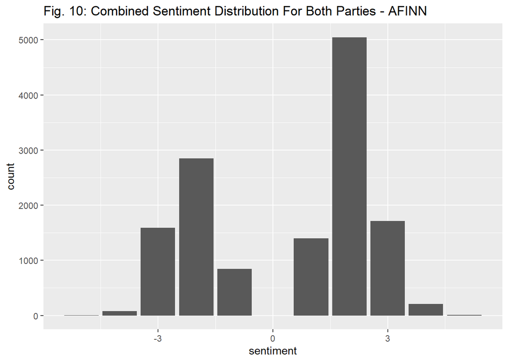

Fig. 10: Sentiment distribution since 1992 fo Both Parties - AFINN

```r
sentiment_debate_words %>%
  filter(grepl("[RD]", party)) %>%
  filter(year >= 1992) %>%
  count(value) %>%
  ggplot(aes(x = value, y = n)) +
  geom_col() +
    labs(title = "Fig. 10: Combined Sentiment Distribution For Both Parties - AFINN",
       x = "sentiment",
       y = "count")
```

```r
save_plot_pdf("fig_10")
```

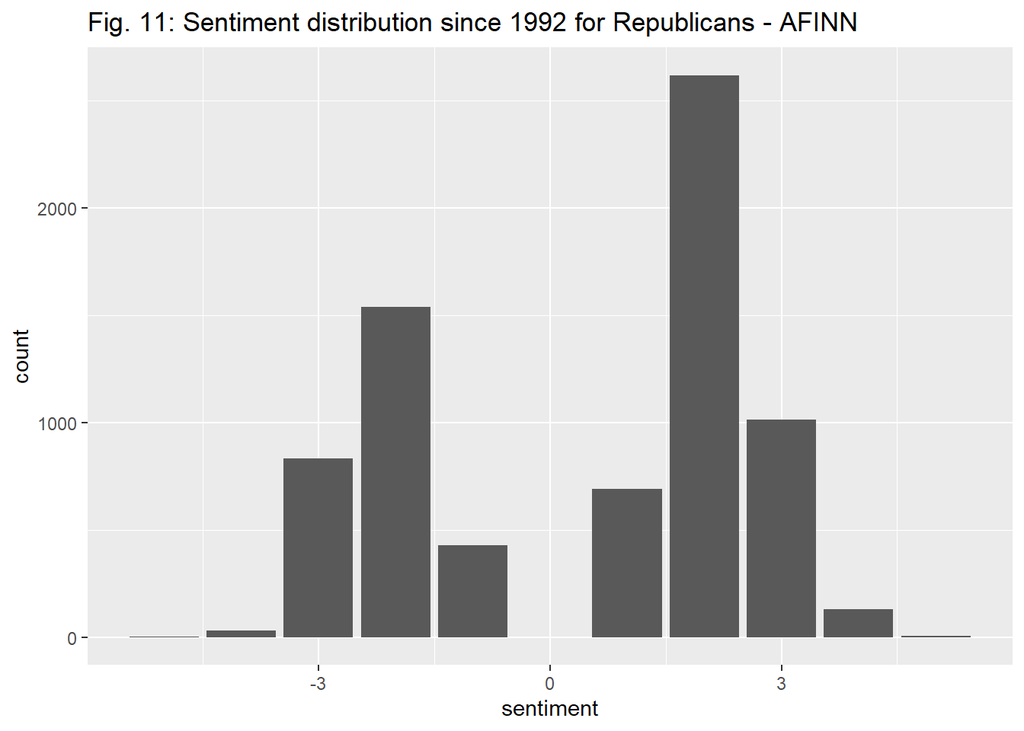

Fig. 11: Sentiment distribution since 1992 for Republicans - AFINN

```r
sentiment_debate_words %>%
  filter(party == "R") %>%
  filter(year >= 1992) %>%
  count(value) %>%
  ggplot(aes(x = value, y = n)) +
  geom_col() +
    labs(title = "Fig. 11: Sentiment distribution since 1992 for Republicans - AFINN",
       x = "sentiment",
       y = "count")
```

```r
save_plot_pdf("fig_11")
```

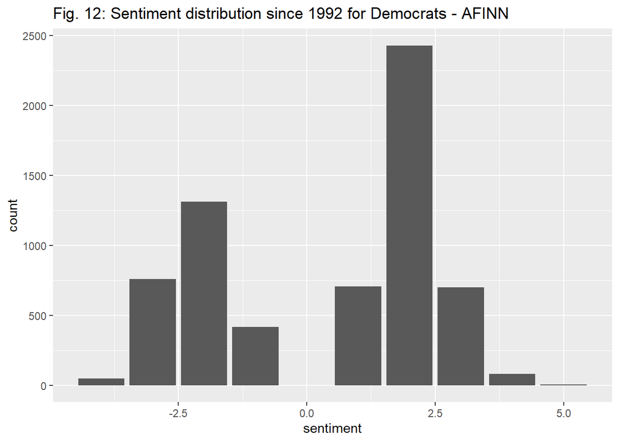

```r
sentiment_debate_words %>%
  filter(party == "D") %>%
  filter(year >= 1992) %>%
  count(value) %>%
  ggplot(aes(x = value, y = n)) +
  geom_col() +
    labs(title = "Fig. 12: Sentiment distribution since 1992 for Democrats - AFINN",
       x = "sentiment",
       y = "count")
```

```r
save_plot_pdf("fig_12")
```

### Plot sentiment each year

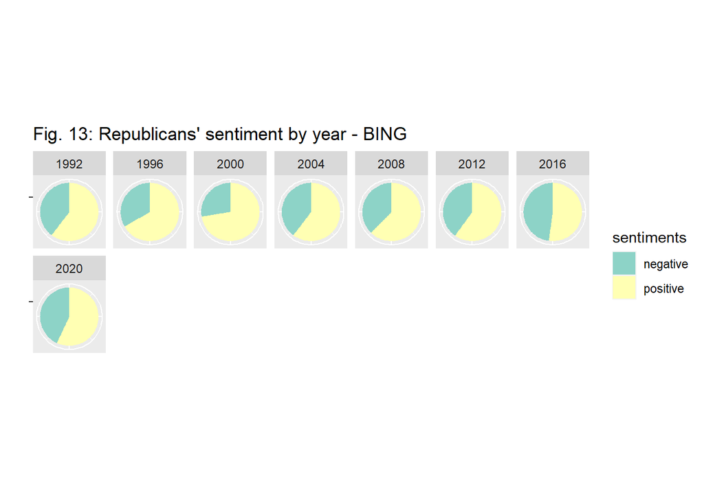

Fig. 13: Republicans’ sentiment for each year - BING

```r
#Republicans
sentiment_debate_words %>%
  filter(party == "R") %>%
  filter(year >= 1992) %>%
  group_by(year, sentiment) %>%
  tally() %>%
  plot_pie_chart() +
   facet_wrap(~year, ncol = 7) +
  labs(title = "Fig. 13: Republicans' sentiment by year - BING",
       x = "",
       y = "",
       fill = "sentiments")
```

```r
save_plot_pdf("fig_13")
```

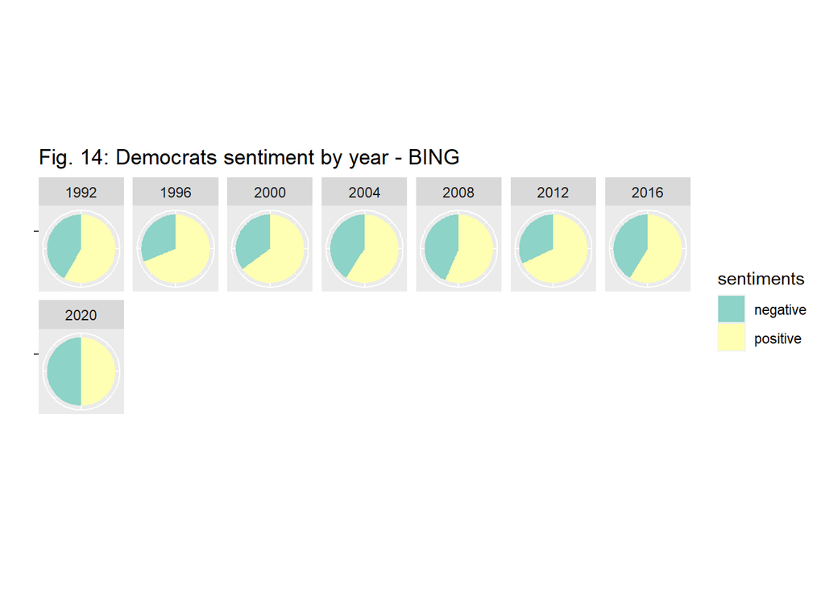

Fig. 14: Democrats’ sentiment for each year - BING

```r
#Democrats
sentiment_debate_words %>%
  filter(party == "D") %>%
  filter(year >= 1992) %>%
  group_by(year, sentiment) %>%
  tally() %>%
  plot_pie_chart() +
  facet_wrap(~year, ncol = 7) +
  labs(title = "Fig. 14: Democrats sentiment by year - BING",
       x = "",
       y = "",
       fill = "sentiments")
```

```r
save_plot_pdf("fig_14")
```

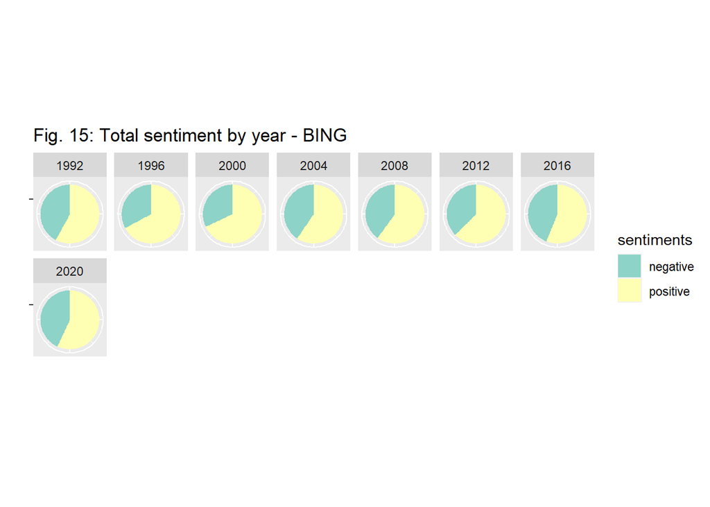

Fig. 15: Combined sentiment for each year - BING

```r
#All
sentiment_debate_words %>%
  filter(year >= 1992) %>%
  group_by(year, sentiment) %>%
  tally() %>%
  plot_pie_chart() +
  facet_wrap(~year, ncol = 7) +
  labs(title = "Fig. 15: Total sentiment by year - BING",
       x = "",
       y = "",
       fill = "sentiments")
```

```r
save_plot_pdf("fig_15")
```

Is there a correlation between when they were in power and how positive they were? Remember to filter out words like “vice”.

### Bigrams

```r
negation_words <- c("not", "no", "never", "without")

all_debates_bigrams <- all_debates %>%
  unnest_tokens(bigram, text, token = "ngrams", n = 2) %>%
  separate(bigram, c("word1", "word2"), sep = " ") %>%
  filter(word1 %in% negation_words) %>%
  inner_join(get_sentiments("afinn"), by = c(word2 = "word"))

save_plot_pdf("fig_16")
```

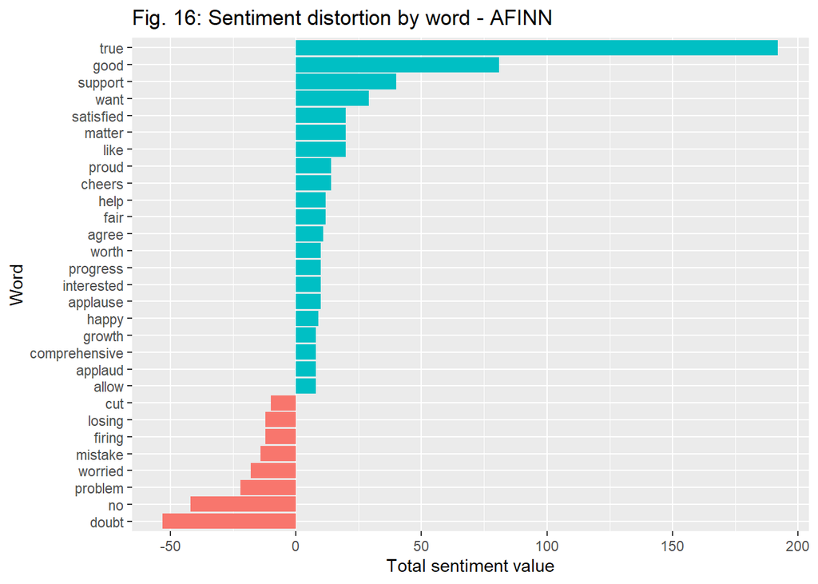

Fig. 16: Top 30 words that distorts the total sentiment most

```r
all_debates_bigrams %>%
  count(word1, word2, value, sort = TRUE) %>%
  mutate(contribution = n * value) %>%
  arrange(desc(abs(contribution))) %>%
  head(30) %>%
  mutate(word2 = reorder(word2, contribution)) %>%
  arrange(desc(n)) %>%
  ggplot(aes(n * value, word2, fill = n * value > 0)) +
  geom_col(show.legend = FALSE) +
  labs(title = "Fig. 16: Sentiment distortion by word - AFINN",
       x = "Total sentiment value",
       y = "Word")
```

```r
save_plot_pdf("fig_16")
```

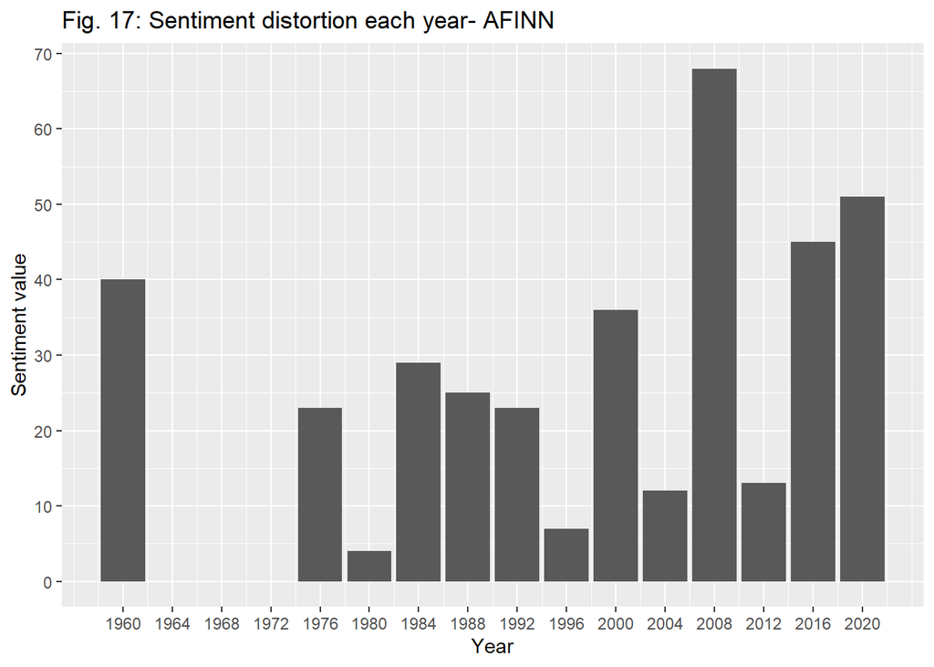

Fig. 17: How each year’s sentiment is distorted

```r
all_debates_bigrams %>%
  count(word1, word2, year, value, sort = TRUE) %>%
  mutate(contribution = n * value) %>%
  group_by(year) %>%
  summarise(total = sum(contribution)) %>%
  ggplot(aes(x = year, y = total), stat = "identity") +
  geom_col() +
  scale_x_continuous(breaks=seq(1960, 2020, by = 4)) +
  scale_y_continuous(breaks = seq(0, 70, by = 10)) +
  labs(title = "Fig. 17: Sentiment distortion each year- AFINN",
       x = "Year",
       y = "Sentiment value")
```

```r
save_plot_pdf("fig_17")
```

## Combining Sentiment and wordclouds

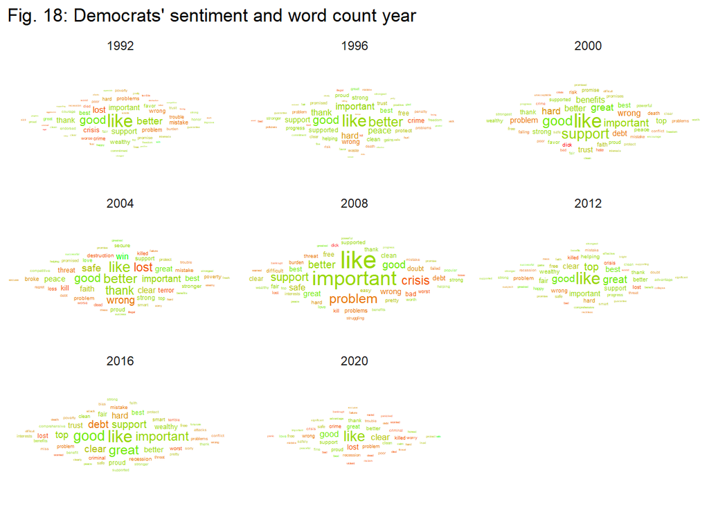

Fig. 18: Democratic word cloud. The size of each word is the count, the color is the sentiment

```r
sentiment_debate_words %>%
  filter(party == "D") %>%
  filter(year >= 1992) %>%
  count(year, word, value, sort = TRUE) %>%
  group_by(year) %>%
  slice_max(order_by  = n, n= 50) %>%
  plot_wordclouds(color_value = value) +
  scale_color_gradient(low = "red", high = "green") +
    facet_wrap(~year, ncol = 3) +
  labs(title = "Fig. 18: Democrats' sentiment and word count year")
```

```r
save_plot_pdf("fig_18")
```

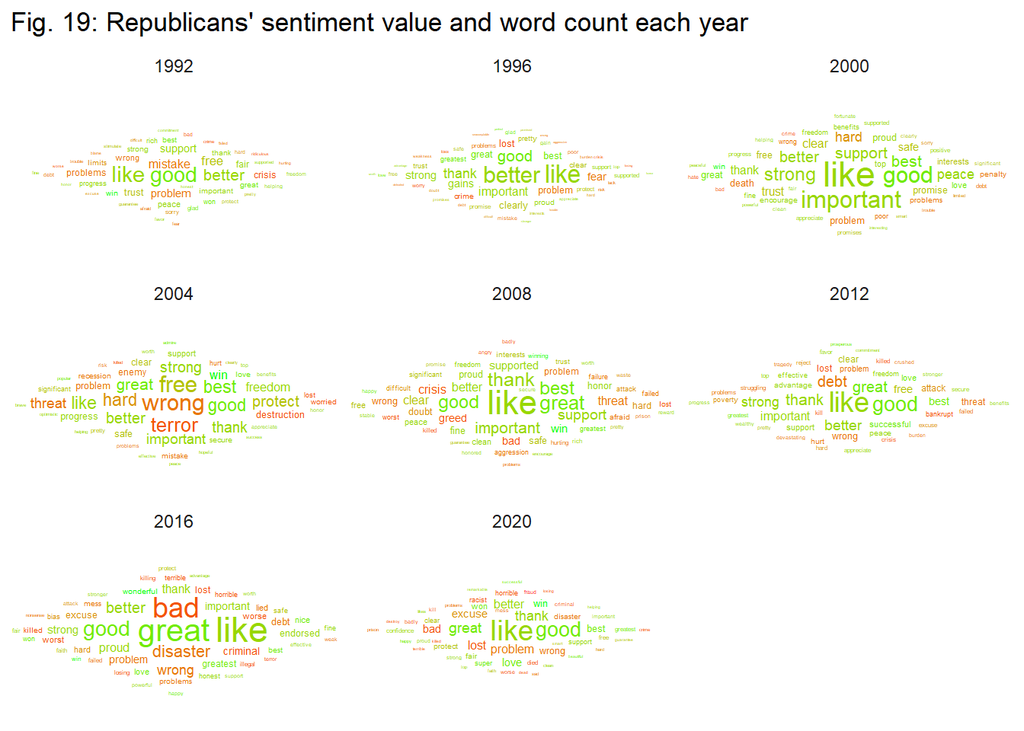

Fig. 19: Republican word cloud. The size of each word is the count, the color is the sentiment

```r
sentiment_debate_words %>%
  filter(party == "R") %>%
  filter(year >= 1992) %>%
  count(year, word, value, sort = TRUE)  %>%
  group_by(year) %>%
  slice_max(order_by = n,n= 50) %>%
  plot_wordclouds(color_value = value) +
  scale_color_gradient(low = "red", high = "green" ) +
  facet_wrap(~year, ncol = 3) +
  labs(title = "Fig. 19: Republicans' sentiment value and word count each year")
```

```r
save_plot_pdf("fig_19")
```

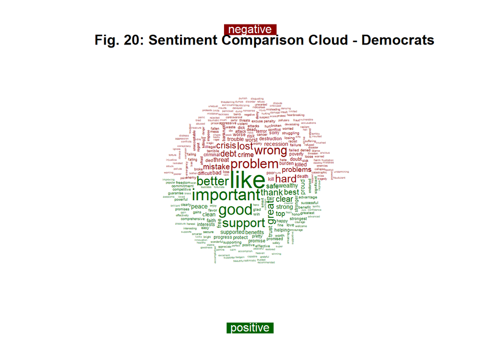

Fig. 20: Comparison cloud for Democrats

```
## integer(0)
```

```r
sentiment_debate_words %>%
  filter(party == "D") %>%
  filter(year >= 1992) %>%
  count(word, sentiment, sort = TRUE) %>%
  acast(word ~ sentiment, value.var = "n", fill = 0) %>%
  create_comparison_cloud(title_value = "Fig. 20: Sentiment Comparison Cloud - Democrats")
```

```r
save_plot_pdf("fig_20")
```

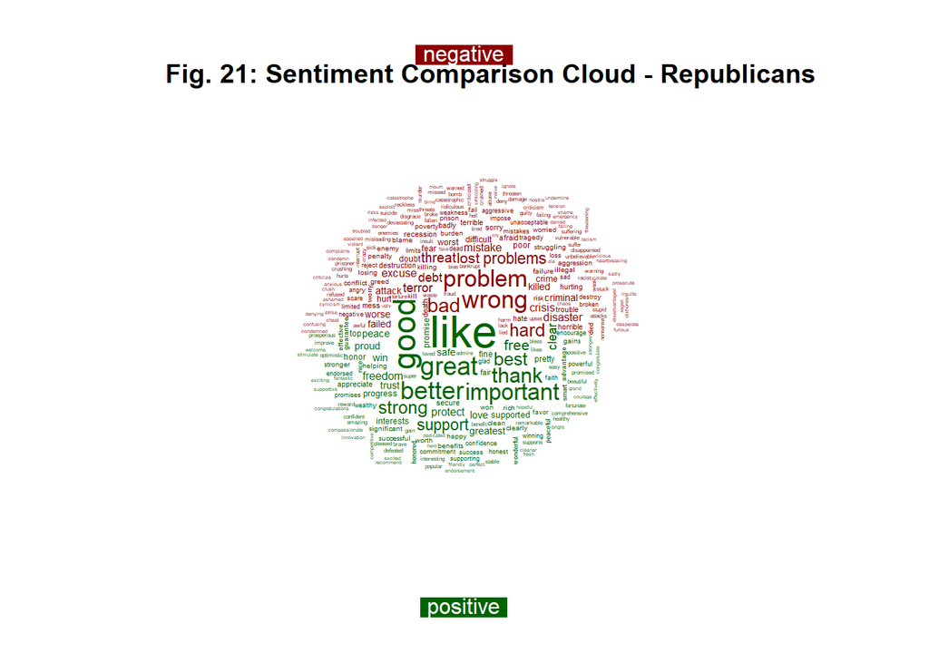

```
## integer(0)
```

```r
sentiment_debate_words %>%
  filter(party == "R") %>%
  filter(year >= 1992) %>%
  count(word, sentiment, sort = TRUE) %>%
  acast(word ~ sentiment, value.var = "n", fill = 0) %>%
  create_comparison_cloud(title_value = "Fig. 21: Sentiment Comparison Cloud - Republicans")
```

```r
save_plot_pdf("fig_21")
```

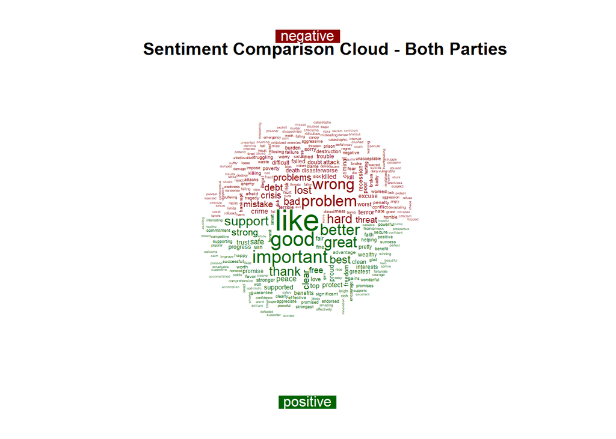

```
## integer(0)
```

```r
sentiment_debate_words %>%
  filter(year >= 1992) %>%
  filter(grepl("[RD]", party)) %>%
  count(word, sentiment, sort = TRUE) %>%
  acast(word ~ sentiment, value.var = "n", fill = 0) %>%
  create_comparison_cloud(title_value = "Sentiment Comparison Cloud - Both Parties")
```

```r
save_plot_pdf("fig_22")
```

# Literature

(Wickham, 2014) (datacarpentry.org, n.d.): https://datacarpentry.org/spreadsheets-socialsci/03-dates-as-data/index.html

**Packages** Zeileis A, Grothendieck G (2005). “zoo: S3 Infrastructure for Regular and Irregular Time Series.” Journal of Statistical Software, 14(6), 1–27. doi: 10.18637/jss.v014.i06.

Garrett Grolemund, Hadley Wickham (2011). Dates and Times Made Easy with lubridate. Journal of Statistical Software, 40(3), 1-25. URL http://www.jstatsoft.org/v40/i03/.

Karl W. Broman & Kara H. Woo (2018) Data Organization in Spreadsheets, The American Statistician, 72:1, 2-10, DOI: 10.1080/00031305.2017.1375989